# Southern hake reference points with Eqsim-WD WGBIE 2026

# The ICES approach to setting Reference Points

This Markdown document outlines the steps involved in estimating PA and MSY reference points for hake in divisions 8.c and 9.a, Southern stock, as part of the WD entitled “Model Improvements for Southern Hake Stock (hke.27.8c9a)”, the process follows the code used in the WKAngHake benchmark 2022, and the guidelines:

[Details here.](https://www.ices.dk/sites/pub/Publication%20Reports/Guidelines%20and%20Policies/16.04.03.01_Reference_points_for_category_1_and_2.pdf)

## Get the data in FLR

```r
# Load library
library(r4ss)
library(ss3om)      # for readLFSss3
library(FLCore)
library(msy)        # install_github("ices-tools-prod/msy")
library(icesAdvice)
library(ggplot2)
library(dplyr)

# Directory
dir <- getwd()
ass.wd=paste(dir, "/6. Gislason M",sep="")

# SS3 output

replist <- SSgetoutput(dirvec = ass.wd, getcovar = F, verbose = FALSE)[[1]]


# FLR objects

hke.stk <- readFLSss3(ass.wd)  # FLStock

hke.sr  <- readFLSRss3(ass.wd) # FLSR

dnms <- dimnames(hke.stk)

# Characteristics
# - ages
ages  <- as.numeric(dnms$age);ages
```

```
##  [1]  0  1  2  3  4  5  6  7  8  9 10 11 12 13 14 15
```

```r
# - years
yrs   <- as.numeric(dnms$year);yrs
```

```
##  [1] 1960 1961 1962 1963 1964 1965 1966 1967 1968 1969 1970 1971 1972 1973 1974
## [16] 1975 1976 1977 1978 1979 1980 1981 1982 1983 1984 1985 1986 1987 1988 1989
## [31] 1990 1991 1992 1993 1994 1995 1996 1997 1998 1999 2000 2001 2002 2003 2004
## [46] 2005 2006 2007 2008 2009 2010 2011 2012 2013 2014 2015 2016 2017 2018 2019
## [61] 2020 2021 2022 2023
```

```r
# - units
units <- dnms$unit;units
```

```
## [1] "F2" "F3" "M2" "M3"
```

```r
# - seasons
ssons <- as.numeric(dnms$season);ssons
```

```
## [1] 1 2 3 4
```

```r
hke.stk@range['minfbar'] <- 1
hke.stk@range['maxfbar'] <- 7
```

## Collapse to one season and unit

```r
stk <- nounit(hke.stk) # combine sexes
stk <- noseason(stk)   # combine seasons
```

### Recruitment correction

```r
raf <-  stock.n(hke.stk)[1,,"F2",2,] + stock.n(hke.stk)[1,,"F3",3,]
ram <-  stock.n(hke.stk)[1,,"M2",2,] + stock.n(hke.stk)[1,,"M3",3,]
stock.n(stk)[1,] <- raf + ram
```

### Natural mortality correction

```r
mf <- replist$M_at_age %>% filter(Sex == 1 & Yr %in% yrs) %>% select(Yr, '0') %>%
  tidyr::pivot_wider(names_from = Yr, values_from = '0') %>% unlist()
mm <- replist$M_at_age %>% filter(Sex == 2 & Yr %in% yrs) %>% select(Yr, '0') %>%
  tidyr::pivot_wider(names_from = Yr, values_from = '0') %>% unlist()
m(stk)[1,] <- (raf * as.numeric(mf) + ram * as.numeric(mm))/(raf+ram)

mat(stk)[1,] <- 0
```

### Correct harvest

```r
harvest(stk) <-  harvest(stock.n(stk), catch=catch.n(stk), m=m(stk))
```

## Comparison of SSB and recruitment values

We compare the SSB from SS3 (only for females) with the one in the FLStock (both sexes).

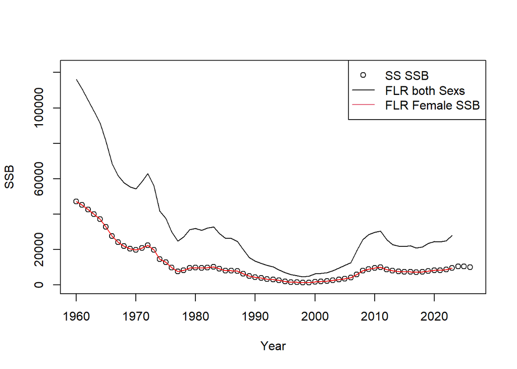

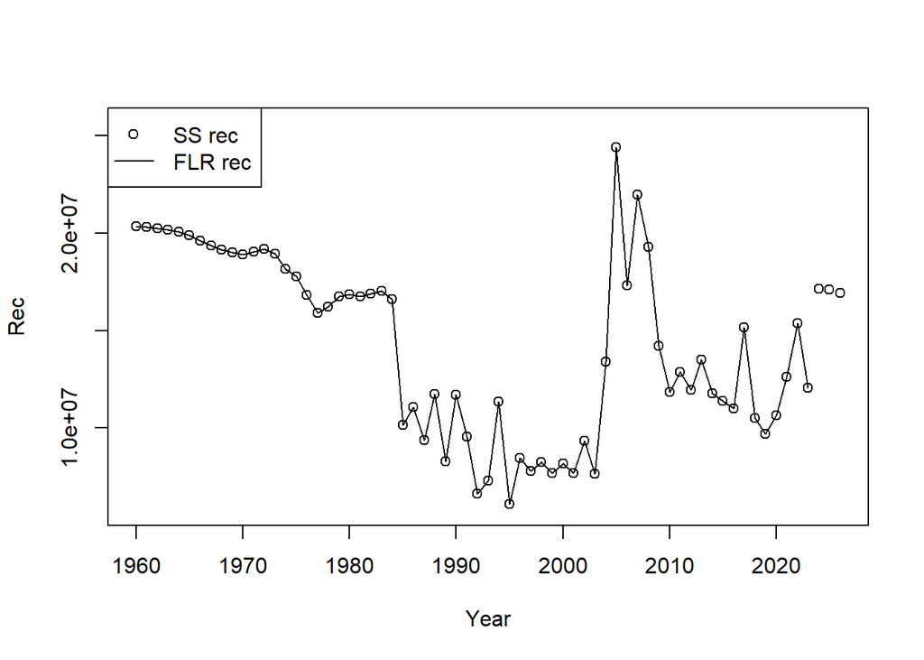

### Corrected maturity to get only-female SSB

```r
alpha <- c(SSssb$Value[1:(length(yrs))]/ssb(stk)[,,])

mat(stk) <- sweep( mat(stk), 2, alpha, "*")
```

### Summary of FLStock object

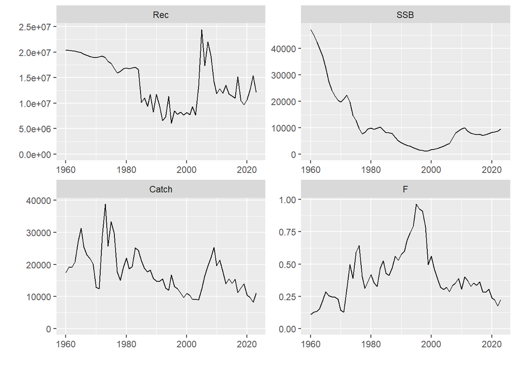

```r
plot(stk) + facet_wrap(~qname, scales="free")
```

## Stock-recruit relationship (Bevholt Stock-recruit)

We take the data from 1982 onwards.

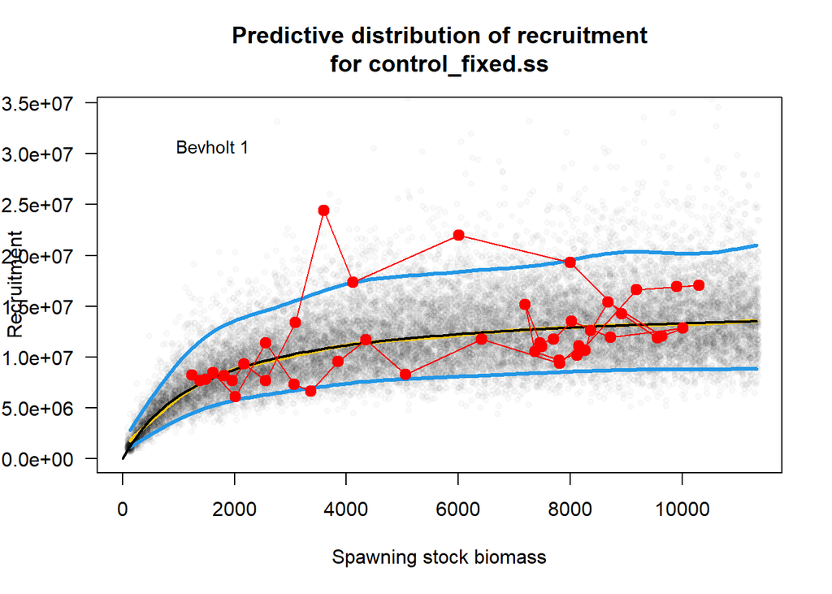

```r
stk <- window(stk,start=1982,end=2023)
srr <- window(hke.sr,start=1982,end=2023)
#srr <- hke.sr
set.seed(1)
nsamp <- 1000
fit_bh <- eqsr_fit(stk, nsamp = nsamp, models = c("Bevholt"))
eqsr_plot(fit_bh,ggPlot=FALSE)
```

## Setting Blim

The stock is type 2 (with a wide dynamic range of SSB, and evidence that recruitment is or has been impaired). So in this case, Blim is the breakpoint of the segmented regression.

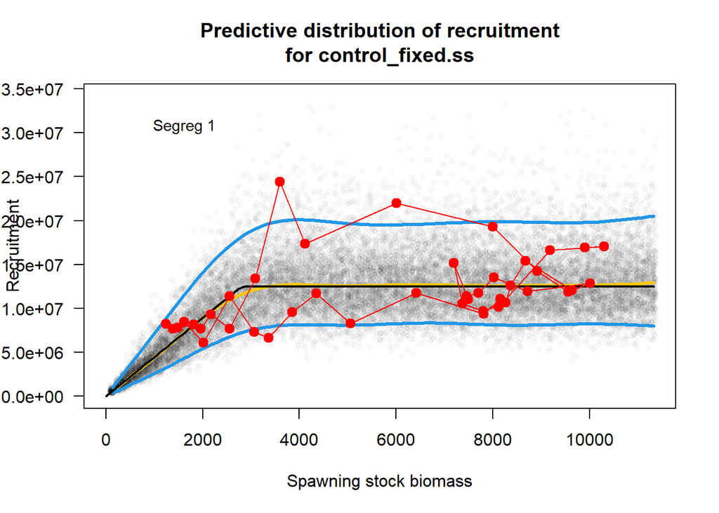

```r
nsamp=1000
SRmodelname <- "Segreg"
fit_seg=msy::eqsr_fit(stk,nsamp=nsamp, models = c(SRmodelname))
eqsr_plot(fit_seg,ggPlot=FALSE)
```

```r
Blim <- fit_seg$sr.det[['b']];Blim
```

```
## [1] 2802.592
```

Blim is estimated at 2802.592.

## Setting Bpa

```r
sigmaSSB<- round(with(subset(replist$derived_quants,Label=='SSB_2023'),StdDev/Value),3)
sigmaSSB
```

```
## [1] 0.144
```

```r
#sigmaSSB <- 0.2 # default

Bpa <- round(Blim * exp(1.645 * sigmaSSB))
```

Bpa is Blim plus assessment error: 3552.

## Setting Flim

Flim: The preferred method is simulating a stock with a segmented regression S–R relationship, with the point of inflection at Blim, thus determining the F = Flim which, at equilibrium, yields a 50% probability of SSB > Blim. Note that this simulation should be conducted based on a fixed F (i.e. without inclusion of a Btrigger) and without inclusion of assessment/advice errors. This means Btrigger, Fcv, and Fphi should all be set to zero

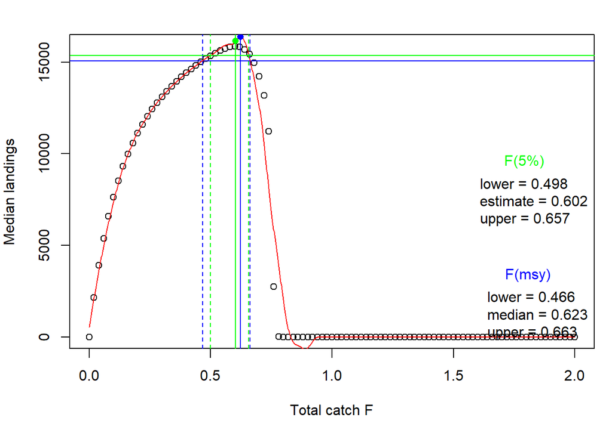

```r
rho <- replist$parameters$Value[replist$parameters$Label=="SR_autocorr"]
sim_segregBlim <- eqsim_run(fit_seg,
                            Fcv=0, Fphi=0, SSBcv=0,
                            rhologRec=rho,
                            Btrigger = 0, Blim=Blim,Bpa=Bpa,
                            Nrun=500, Fscan = seq(0,2,len=101),verbose=F)

Flim <- round(sim_segregBlim$Refs2['catF','F50'],3)
eqsim_plot_range(sim_segregBlim, type="median")
```

Flim is estimated at 0.696.

## $F_{msy}$ (without MSY Btrigger)

$F_{msy}$ should initially be calculated based on an evaluation with the inclusion of stochasticity in a population (i.e. recruitment, M, maturity, growth) and fishery (e.g. selectivity) as well as assessment/advice error. This is a constant F, which should provide maximum yield without biomass constraints (without MSY Btrigger). Error is included as this is the condition analogous to management strategy evaluations (MSEs) that will prevail in practice. Note that in order to ensure consistency between the precautionary and the MSY frameworks, $F_{msy}$ is not allowed to be above Fpa; therefore, if the $F_{msy}$ value calculated initially is above Fpa, $F_{msy}$ is reduced to Fpa.

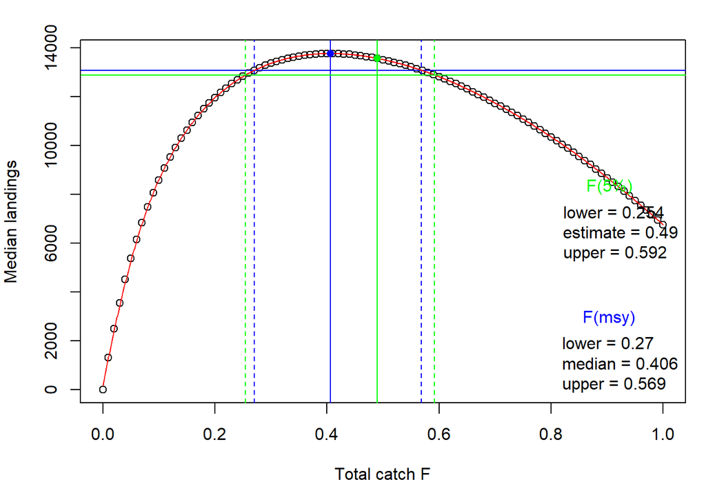

```r
cvF  <- 0.212                                 # Default = 0.212
phiF <- 0.423                                 # Default = 0.423
# SSB
cvSSB <- 0                                    # Default = 0
phiSSB <- 0                                   # Default = 0


sim_noTrig <- eqsim_run(fit_bh,
                            Fcv=cvF, Fphi=phiF, SSBcv=cvSSB,
                            rhologRec=rho,
                            Btrigger = 0, Blim=Blim,Bpa=Bpa,
                            Nrun=500, Fscan = seq(0,1,len=101),verbose=F)

Fmsy_tmp <- round(sim_noTrig$Refs2["lanF","medianMSY"],3)
eqsim_plot_range(sim_noTrig, type="median")
```

```r
png("simfmsy_tmp.png", width = 1600, height = 1400, res = 300)
eqsim_plot_range(sim_noTrig, type="median")
dev.off()
```

$F_{msy}$ is initially estimated as 0.406. Note that SS estimates $F_{msy}$ at 0.329.

## Set Btrigger

MSY Btrigger should be selected to safeguard against an undesirable or unexpected low SSB when fishing at $F_{msy}$. For most stocks that lack data on fishing at $F_{msy}$, MSY Btrigger is set at Bpa. However, as a stock starts to be fished consistently with $F_{msy}$, it is possible to move towards implementation of a value for MSY Btrigger that reflects the 5th percentile definition of MSY Btrigger.

```r
data.05<-sim_segregBlim$rbp
x.05 <- data.05[data.05$variable == "Spawning stock biomass", ]$Ftarget
b.05 <- data.05[data.05$variable == "Spawning stock biomass", ]$p05
plot(b.05~x.05, ylab="SSB", xlab="F")
abline(v=Fmsy_tmp)
i <- which(x.05<Flim)
b.lm <- loess(b.05[i] ~ x.05[i])
lines(x.05[i],c(predict(b.lm)),type='l')

Bmsy5pc <- round(predict(b.lm,Fmsy_tmp))
Bmsy5pc
```

```
## [1] 4995
```

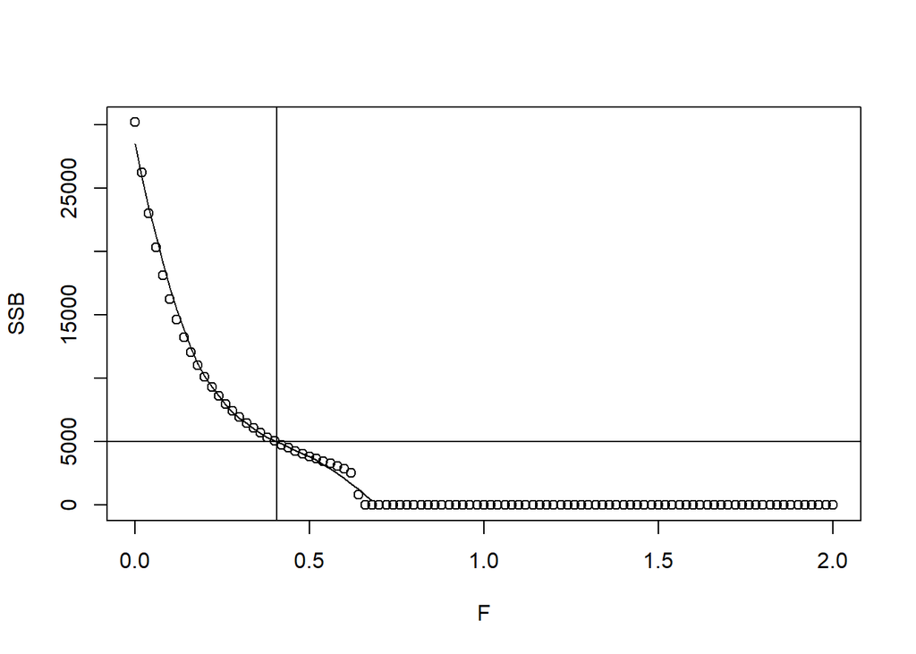

```r
abline(h=Bmsy5pc)
```

So we can use Btrigger = Bpa =3,552 or we can use Bmsy5pc = 4,995. Bpa is lower so go with that.

```r
Btrigger <-min(Bpa,Bmsy5pc)
Btrigger
```

```
## [1] 3552
```

### $F_{msy}$ using Btrigger

The ICES MSY AR should be evaluated to check that the $F_{msy}$ and MSY Btrigger combination fulfills the precautionary criterion of having less than 5% annual probability of SSB < Blim in the long term. The evaluation must include realistic assessment/advice error and stochasticity in population biology and fishery selectivity.

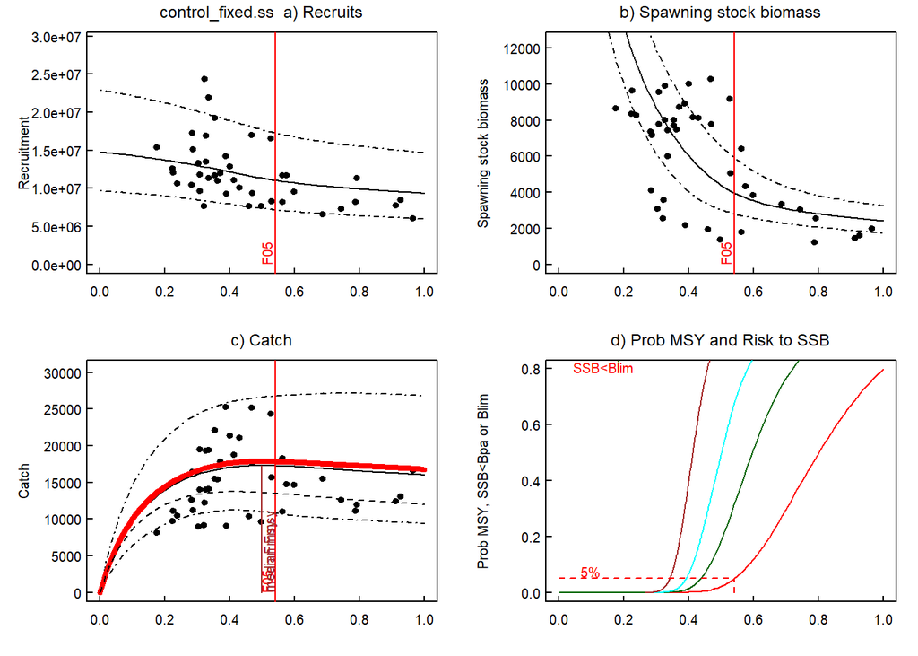

```r
sim_Trig <- eqsim_run(fit_bh,
                          Fcv=cvF, Fphi=phiF, SSBcv=cvSSB,
                          rhologRec=rho,
                          Btrigger = Btrigger, Blim=Blim,Bpa=Bpa,
                          Nrun=1000, Fscan = seq(0,1,len=101),verbose=F)
eqsim_plot(sim_Trig)
```

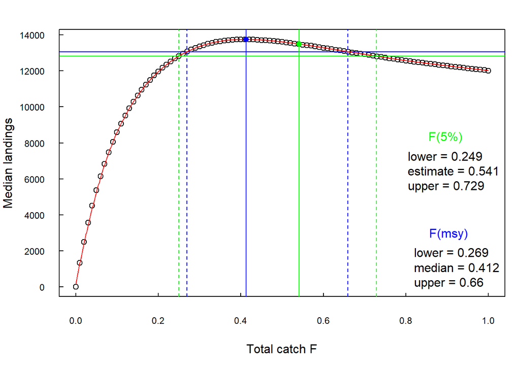

```r
eqsim_plot_range(sim_Trig, type="median")
```

```r
Fp05 <- round(sim_Trig$Refs2["catF","F05"],3)
Fp05
```

```
## [1] 0.541
```

```r
png("simfmsy.png", width = 1600, height = 1400, res = 300)
eqsim_plot_range(sim_Trig, type="median")
dev.off()
```

If the precautionary is not met, then $F_{msy}$ should be reduced from the value calculated above until the precautionary criterion is met (i.e. reduce $F_{msy}$ to $F_{msy}$ = Fpa). Fp05 is estimated at 0.541.

```r
Fmsy <- round(sim_Trig$Refs2["lanF","medianMSY"],3)
Fupper <- round(sim_Trig$Refs2["lanF","Medupper"],3)
Flower <- round(sim_Trig$Refs2["lanF","Medlower"],3)
```

## SS RP

```r
BMSY <- replist$derived_quants$Value[replist$derived_quants$Label=="SSB_MSY"]
FMSY <- replist$derived_quants$Value[replist$derived_quants$Label=="annF_MSY"]
BMSY
```

```
## [1] 11063.8
```

```r
FMSY
```

```
## [1] 0.328861
```

```
##   F_report     SSB Tot_Catch
## 1 0.328861 11063.8   18066.4
```

[output not shown]